# **Data Visualization Course Project**

# Theme - **Environment**

--- By Shivam Kumar Singh

--- 210150022

# Temperature

Let's talk about how Temperatures varied across India, over the months of Year 2019

### First discuss the distribution of Maximum & Minimum Temperature, combined for all the stations to get a overview

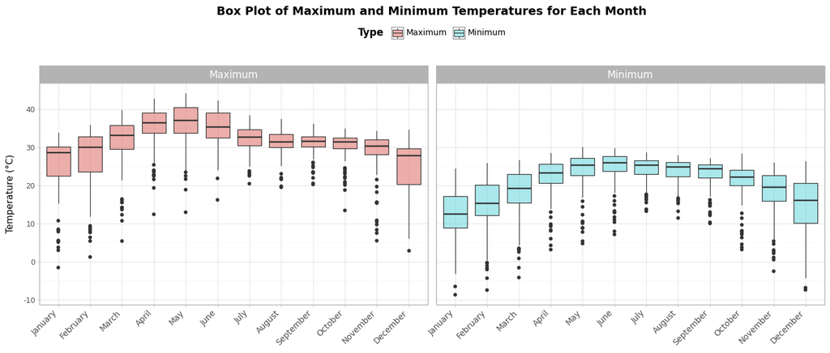

#### Observations ▶

- Temperature varies from about -8°C to 44°C while the mean varies from about 12°C to 37°C.
- Mean maximum Temperature peaked during the month of May while Minimum Temperature peaked during the month of June.
- Mean maximum Temperature was the lowest in December while the Minimum Temperature was lowest in January.
- Outliers exist but these outliers are observed in the lower temperatures scale.

### Now let's discuss how the Temperature varied across the states for every month

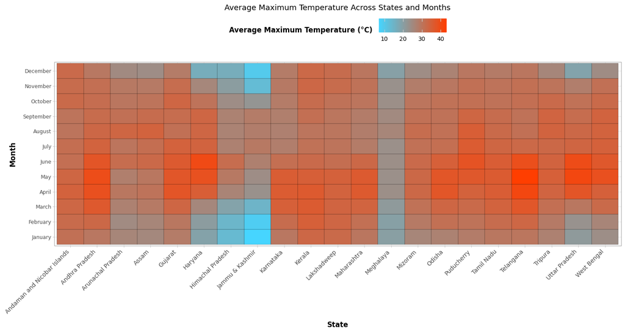

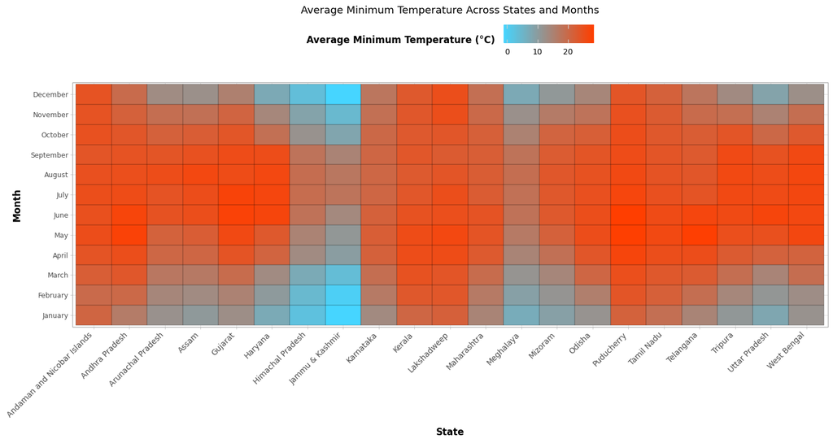

#### Observation ▶

- States/UTs like Kerala, Tamil Nadu, Lakshadweep, Puducherry & Andaman Nicobar seem to have less variation in Temperature across the year as these states/UTs are located in coastal regions in hotter range while Meghalaya has similar climate but in cooler range, maybe because of cloudy climate.
- Maximum average temperature was observed in Telangana in the month of May and Haryana in June while Jammu & Kashmir was the coolest state.
- States like Jammu & Kashmir, Gujarat, Haryana, Andhra Pradesh, Uttar Pradesh & Telangana have higher variation in Temperature across the year.

### It's time to analyse extreme Temperatures

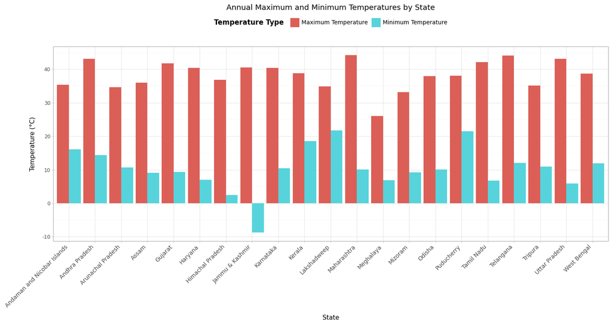

#### Observations ▶

- Maharashtra saw the highest temperature over the year, followed by Telangana, Andhra Pradesh, Uttar Pradesh & Tamil Nadu.
- Jammu & Kashmir saw the lowest temperature over the year, followed by Himachal Pradesh, Uttar Pradesh, Tamil Nadu & Meghalaya.
- Jammu & Kashmir had a high range in temperatures observed during the year (from -8°C to 41°C). Further analysis of Temperature differences is difficult.

#### Requirement of a sorted barplot to analyse the order of temperature difference among the states.

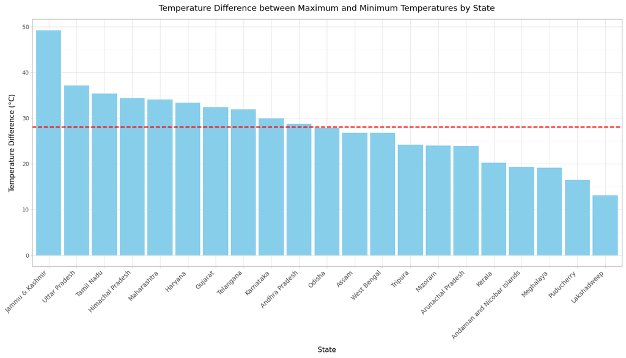

#### Observations ▶

- Among the Top 7 states having high difference between maximum & minimum Temperature, 6 states are landlocked except Tamil Nadu(it could be that some stations in Tamil Nadu observed extreme temperatures due to various factors) while Tamil Nadu had lower variation in average temperature over the year as observed in heatmap earlier.
- Among the Top 5 states having low difference between maximum & minimum Temperature, 4 states belong to coastal regions except Meghalaya (this might be because of cloudy climate), similar observations could be seen in heatmap.
- Average extreme difference across all the states lies somewhere around 28°C which matches with that of Odisha.

### Visualization on Indian Map

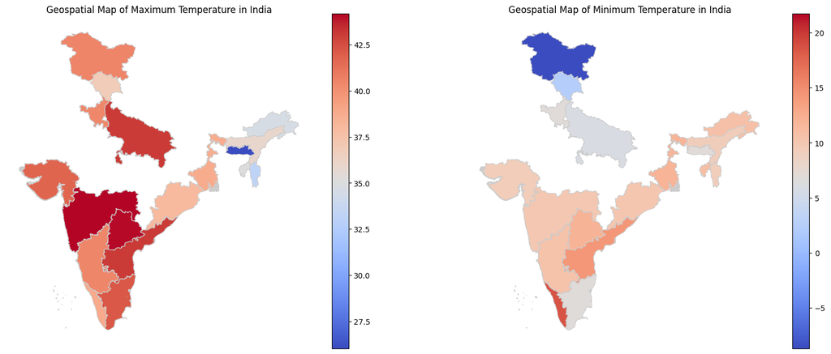

#### Observations ▶

- Lack of sufficient data for some states (which are not visible in the plot).
- In general, Northern states are cooler than Southern states due to equatorial distance.
- One can be confused from the 1st plot that Meghalaya & Mizoram has lower temperature value than the coolest state Jammu & Kashmir the plot depicts least Maximum temperature, not the least Temperature (can be confirmed by the 2nd plot).

### Analysis of the distribution of frequency of Stations over annual maximum & minimum Temperature

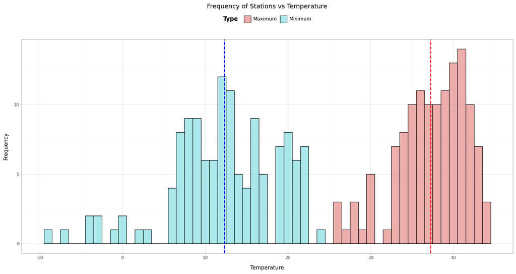

#### Observations ▶

- Mean minimum temperature over all stations is around 12°C while that of the maximum temperature is around 38°C.
- Minimum temperature has higher variance in comparision to maximum temperature.

### How Maximum & Minimum Temperatures are correlated with each other ?

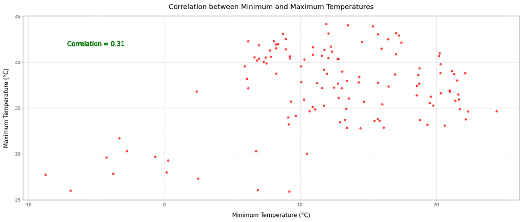

#### Observations ▶

- Minimum & Maximum Temperature are slightly positively correlated with a value of 0.31.

# Rainfall

Let's now talk about how Rainfall varied across India, over the months of Year 2019

### First we discuss the distribution of Rainfall, combined for all the stations to get an overview

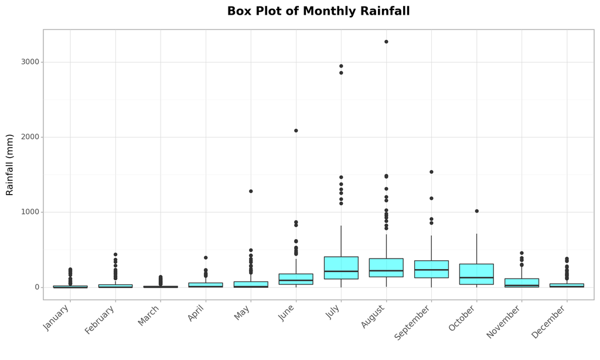

### Analysis of statewise distribution of Rainfall

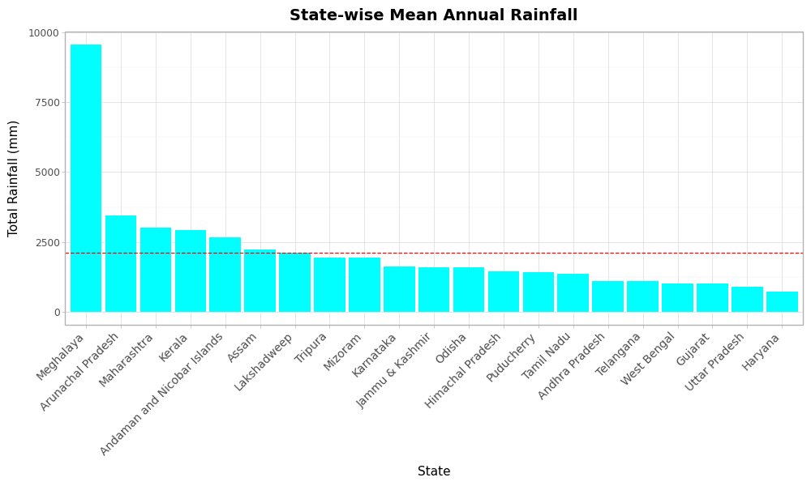

#### Observations ▶

- Meghalaya received almost three times more rainfall than Arunachal Pradesh which ranks in at second place.
- Coastal states like Kerala, UTs like Andaman and Nicobar Island & Lakshadweep receive high rainfall because of its location (proximity to the sea) and direction of wind.
- Northern-eastern states like Assam, Meghalaya, Mizoram and Tripura receive high rainfall because of forest as well as Mountain areas.

### Visualization on Indian Map

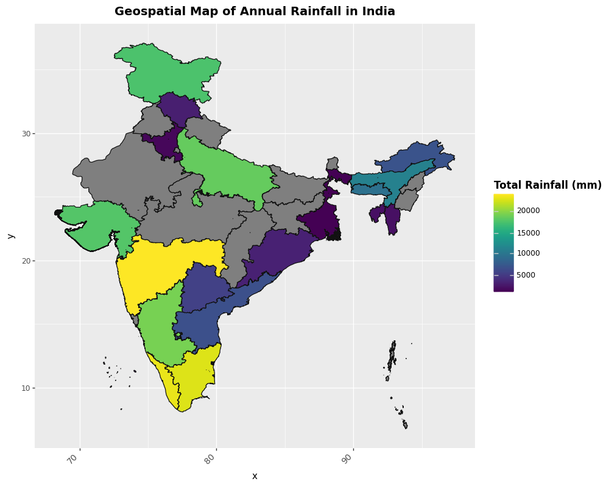

#### Observations ▶

- Why does the Western Ghat Belt receive higher rainfall than its Eastern counterpart?

  ➡ The Western Ghats in India receive rainfall due to orographic rainfall, which occurs when winds from the Arabian Sea climb the slopes of the mountains and cool, causing the windward side to receive heavy rainfall. The winds rise, expand, cool, condense, and shed their moisture on the western slopes, resulting in more rainfall.

### Analysis of top stations which receives highest rainfall

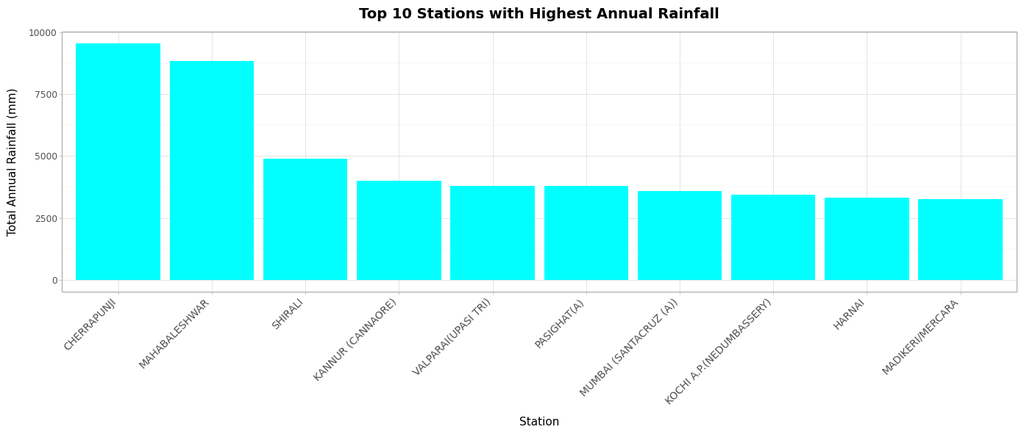

### Rainfall variation across the states for every month

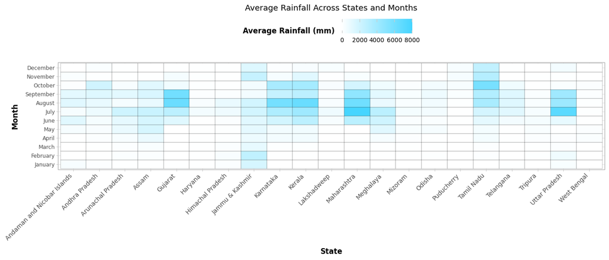

#### Observations ▶

- Most of the states receives rainfall during the months of June to October while Tamil Nadu receives rainfall till December and Jammu & Kashmir receives rainfall almost throughout the entire year except September & October.

### Let's try to find the Correlation between Temperature & Rainfall.

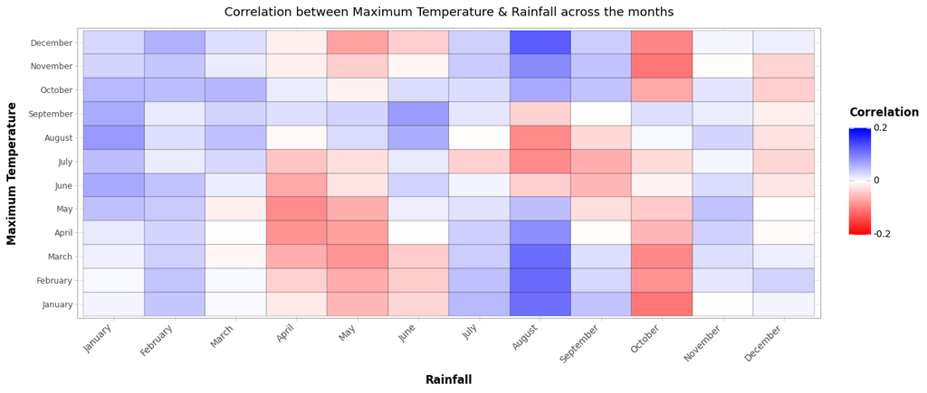

#### Observations ▶

- There's not much correlation which is observed but we can see an alternate pattern of blue and red combination of columns.
- Average temperature data over the months may have higher correlation with rainfall, but I was unable to find such data for these many stations.

### Now we discuss about the changes in Ground Water Level - Pre & Post Monsoon

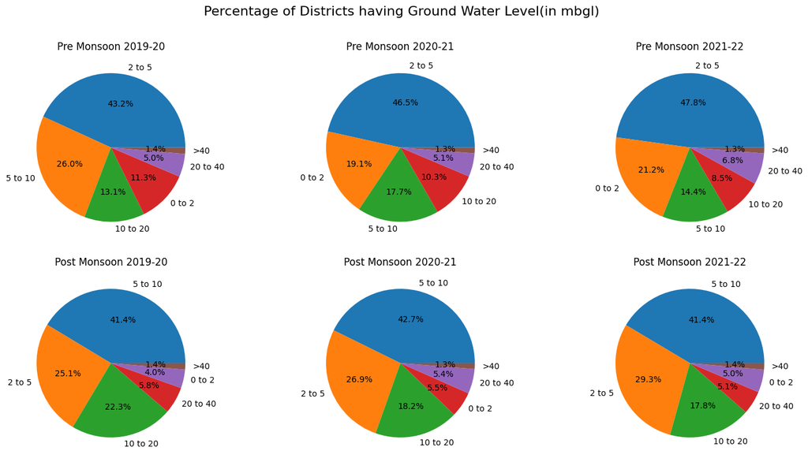

#### Observations ▶

- There's an increase in the percentage of districts having higher ground water level values and a decrease in the percentage of districts with lower water level values post monsoon as compared to pre monsoon.

# Air Quality

Let's now talk about how Air Quality varied across India, over the past few years

### First we see a Nationwide overview of Air Quality for 2015-2020

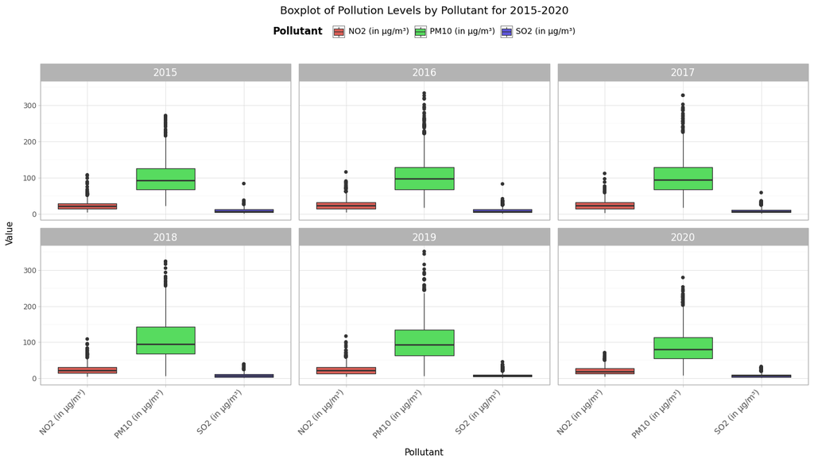

### Now analysis of Air Quality statewise

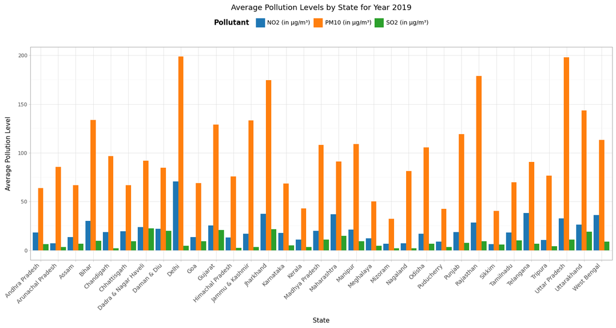

#### Observations ▶

- Delhi has the maximum concentration of PM10 & NO2 as the main sources of these pollutants are brush/waste burning, landfills, wildfires and agriculture (from the surrounding states) & fossil fuels consumed by cars respectively.
- One thing can be observed that States having higher values of PM10, also have higher values of NO2 as compared to other states but SO2 doesn't follow similar trends.
- Jharkhand has the maximum concentration of SO2 which can be attributed to the fact that Industrial gaseous waste is the major source of SO2.
- Mizoram has the least concentration of all the pollutants.

### Visualization on Indian Map

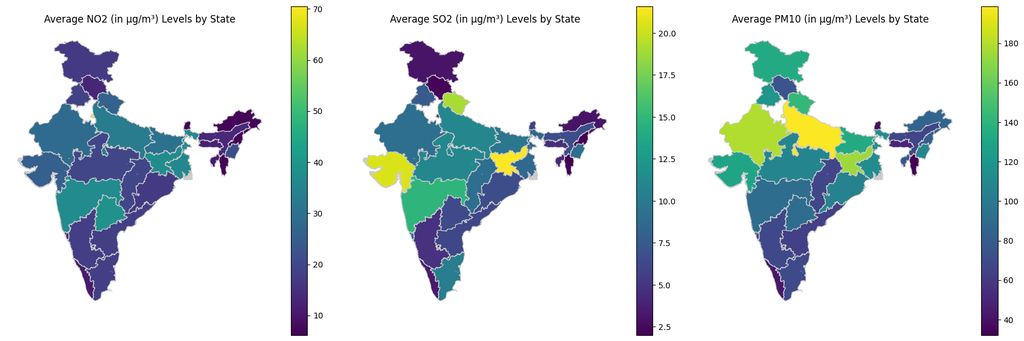

#### Observations ▶

- Southern, North-Eastern & Extreme Northern states have low concentration of all Pollutants.

### Let's check the correlations among the pollutants.

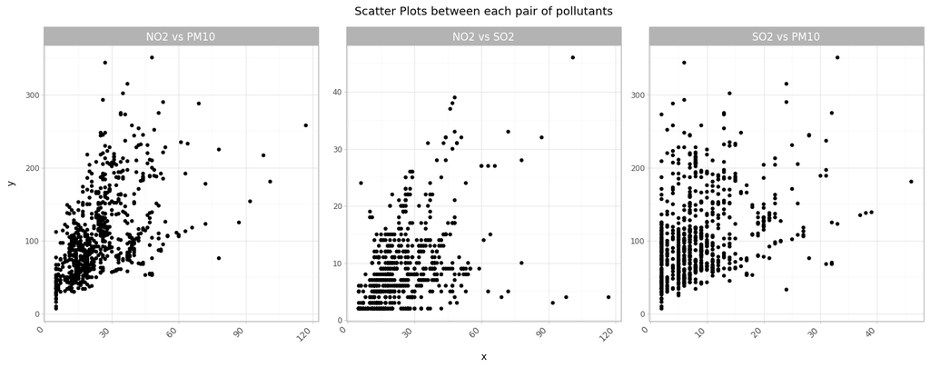

#### Observations ▶

- NO2 and PM10 are more correlated, followed by NO2 and SO2.

### Analysis of the most infamous city for Pollution i.e. Delhi across the past few years

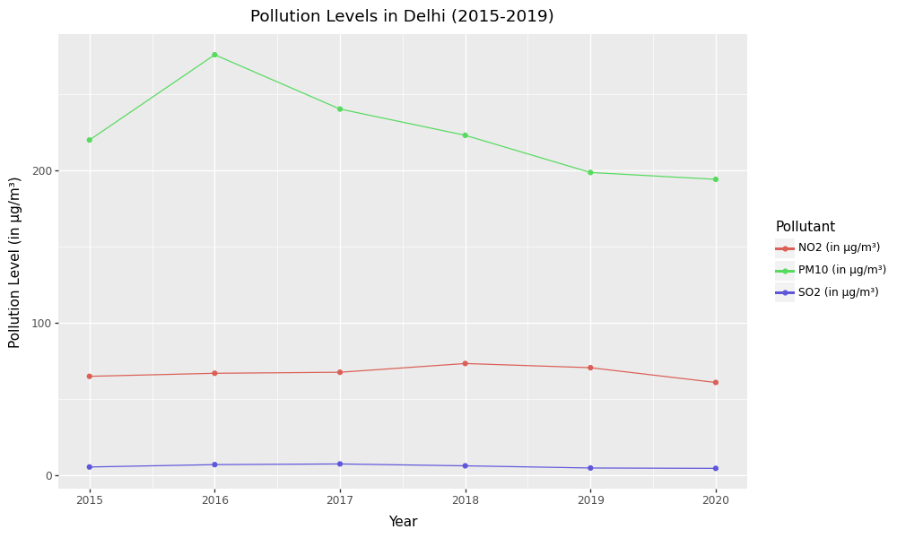

#### Observations ▶

- PM10 concentration peaked in 2016 and started decreasing after that.
- NO2 concentration is almost constant but hiked in 2018.
- Similarly with SO2, concentration was at its peak in the year of 2017.

### Analyssis of Statewise Pollutant Concentration over the years

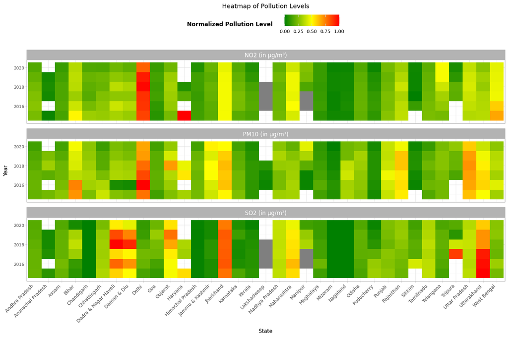

### Frequency of Location vs concentration value of each pollutant

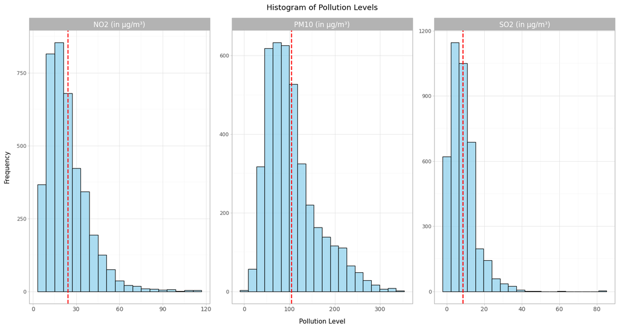

#### Observations ▶

- Mean values of each pollutants for all stations over the years are :-

    PM10 ~ 105 μg/m³

# Forest

Now we're going to focus on Forest Areaa and its type distribution across the country.

### Starting with brief description of types of Forest.

There are 3 types of Forest :-

- Very dense forest (VDF): A canopy density of 70% or higher
- Moderately dense forest (MDF): A canopy density of 40% to more than 70% but less than 70%
- Open forest (OF): A canopy density of 10% or higher but less than 40%

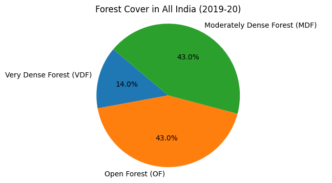

### Now let's how it varies across the states

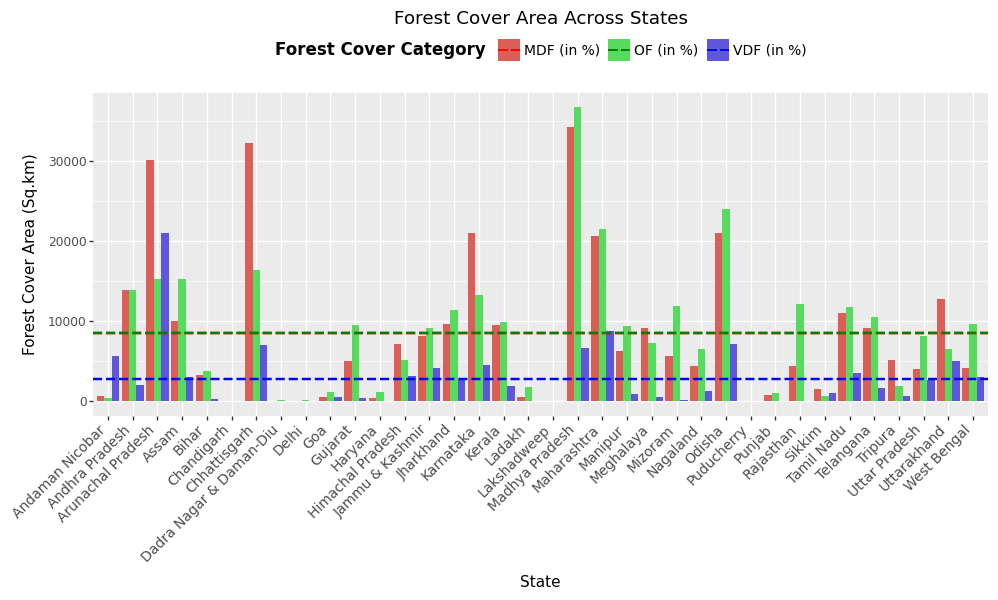

#### Observations ▶

- Madhya Pradesh has the maximum area of MDF & OF, followed by Chhattisgarh and Arunachal Pradesh in MDF & Odisha, Maharashtra, Chattisgarh and Arunachal Pradesh in OF
- Arunachal Pradesh has the maximum area of VDF, with no other state close to it.
- Despite of being smaller in area but highly rich in Forest Area that means it'll have highest percentage of Forest Land as compared to Total Land.

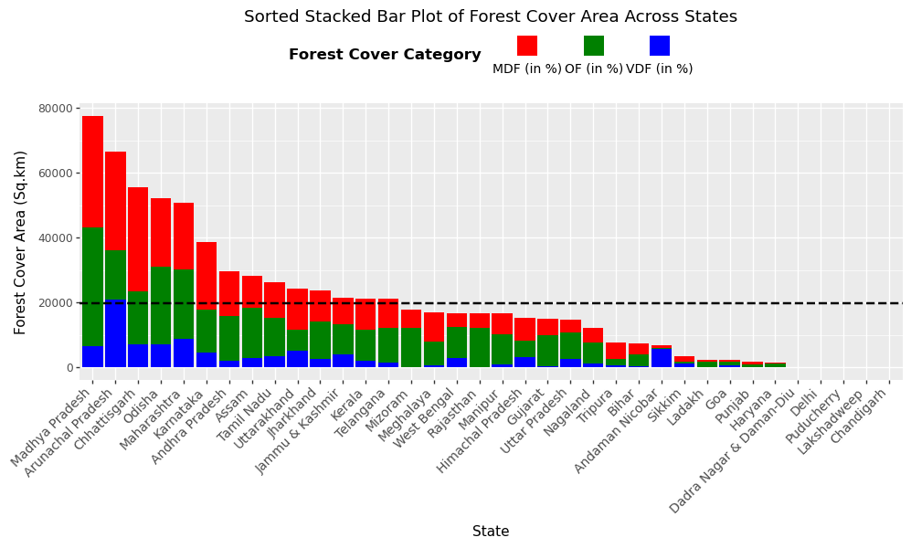

#### Observations ▶

- Madhya Pradesh has the maximum combined Forest Area, followed by Arunachal Pradesh, Chhatisgarh, Odisha & Maharashtra.
- 14 states have higher Forest area than the country average.

### Visualization on Indian Map for each type of Forest distribution

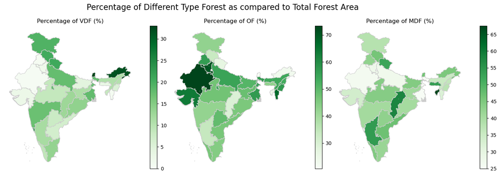

#### Observations ▶

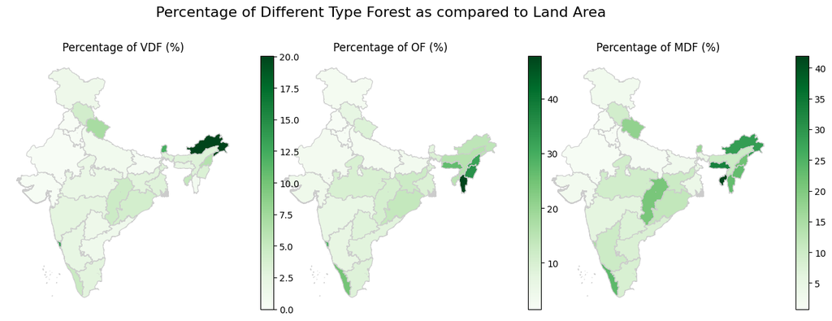

#### Observations ▶

- North-Eastern states have a higher percentage of land area as Forest area. All these states have spikes in colors in at least 2 of the Forest types except Assam.
- Similarly Kerala, Himachal Pradesh, Chhatisgarh, Goa & Sikkim have some spikes in colors in at least 2 of the Forest types

### Let's try to find out the correlation between Forest Cover Area & Total Rainfall received in a state

```
Correlation between Total Rainfall and Percentage of Total Land Area: 0.5546614893846679
```

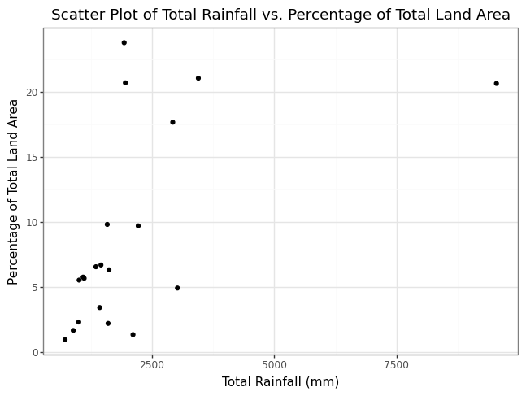

#### Observations ▶

- The correlation is around 0.55 which could be due to Transpiration (a process in which trees and vegetation absorb water through their roots and cool surroundings by releasing water vapor into the air through their leaves).
- Meghalaya is an outlier, because of high Hilly areas.

# Thank You

## The Earth is what we all have in common